### Background:

#### The “Sporting Goods Sales Data” for Q1 2023 presents sales figures for the leading five brands, along with quarterly growth rates. This comprehensive dataset encompasses the company’s nationwide presence and is organized by region and city, offering a detailed insight into its performance during this period.

### Objective:

#### Perform PCA on Q1 2023 sales data for the top 5 brands, categorized by Region and City_Code, aiming to reduce dimensionality while retaining essential information and uncovering latent patterns and relationships among variables.

### Importing Libraries

```r
library(ggplot2)
library(GGally)
library(dplyr)
```

### Importing Data

```r
data<-read.csv("Sporting Goods Sales Data.csv")
head(data)
```

```
  Region City_Code Sales_B1 Growth_B1 Sales_B2 Growth_B2 Sales_B3 Growth_B3
1   EAST       281    45.46      5.87    52.71      5.79    40.18      4.70
2   EAST       282    46.15      6.38    53.54      4.97    41.68      4.11
3   EAST       283    21.83      3.71    26.66      1.78    20.68      1.79
4   EAST       284    49.64      7.04    59.05      4.98    43.00      4.70
5   EAST       285    37.55      5.32    40.22      3.99    34.75      3.30
6   EAST       286    38.37      5.99    44.61      4.75    36.16      3.35
  Sales_B4 Growth_B4 Sales_B5 Growth_B5
1    56.87      4.71    31.81      3.14
2    57.26      5.17    31.63      4.59
3    29.28      1.73    16.32      2.77
4    54.31      3.12    27.33      3.10
5    42.96      3.74    25.48      3.58
6    49.32      3.77    27.64      3.05
```

### Correlation Assessment

```r
# Drop the 'Region' and 'City_Code' columns as they are not needed for PCA
pcadata<-subset(data,select = -c(Region,City_Code))
cor(pcadata)
```

```
           Sales_B1 Growth_B1  Sales_B2 Growth_B2  Sales_B3 Growth_B3  Sales_B4
Sales_B1  1.0000000 0.9035556 0.9766930 0.8504517 0.7675832 0.8154070 0.8259007
Growth_B1 0.9035556 1.0000000 0.8878535 0.9083478 0.8501619 0.8813590 0.8043728
Sales_B2  0.9766930 0.8878535 1.0000000 0.8397925 0.7551729 0.8027523 0.7578874
Growth_B2 0.8504517 0.9083478 0.8397925 1.0000000 0.8013830 0.8390718 0.7721576
Sales_B3  0.7675832 0.8501619 0.7551729 0.8013830 1.0000000 0.9081431 0.8590093
Growth_B3 0.8154070 0.8813590 0.8027523 0.8390718 0.9081431 1.0000000 0.8277393
Sales_B4  0.8259007 0.8043728 0.7578874 0.7721576 0.8590093 0.8277393 1.0000000
Growth_B4 0.8314605 0.8640162 0.7802320 0.8206764 0.8671611 0.8963683 0.8950528
Sales_B5  0.6932055 0.6582148 0.6465255 0.6211279 0.8314281 0.7417905 0.9207339
Growth_B5 0.7353399 0.8506590 0.7243517 0.8272188 0.8493350 0.8424836 0.7205446
          Growth_B4  Sales_B5 Growth_B5
Sales_B1  0.8314605 0.6932055 0.7353399
Growth_B1 0.8640162 0.6582148 0.8506590
Sales_B2  0.7802320 0.6465255 0.7243517
Growth_B2 0.8206764 0.6211279 0.8272188
Sales_B3  0.8671611 0.8314281 0.8493350
Growth_B3 0.8963683 0.7417905 0.8424836
Sales_B4  0.8950528 0.9207339 0.7205446
Growth_B4 1.0000000 0.7907915 0.8047264
Sales_B5  0.7907915 1.0000000 0.5908798
Growth_B5 0.8047264 0.5908798 1.0000000
```

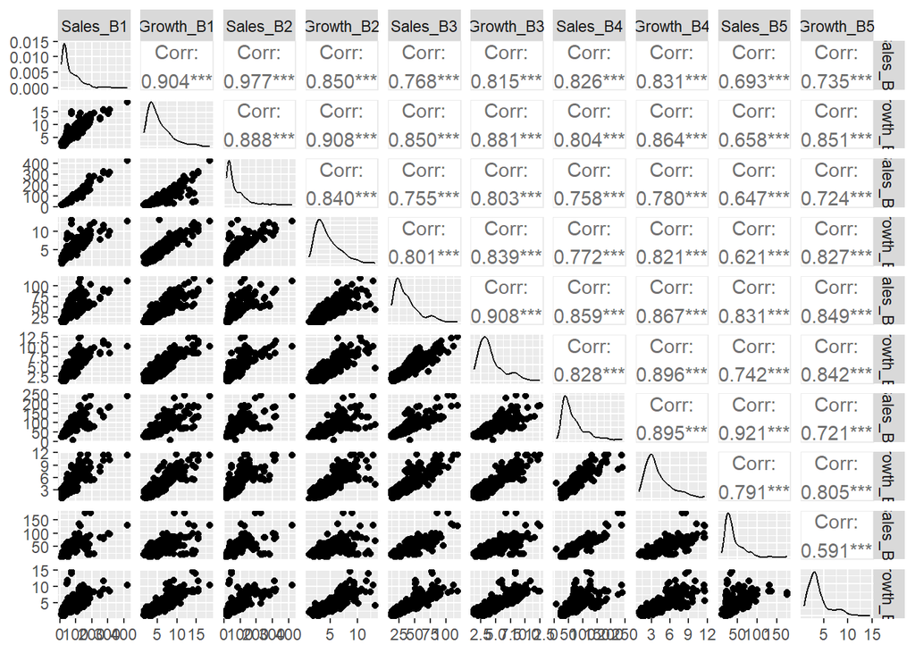

```r
# Create a pair plot
ggpairs(pcadata)
```

### PCA for Dimensionality Reduction

```r
# Standardize the data by scaling it
pcadata<-data.frame(scale(pcadata))

# Run PCA on data
pc<-princomp(formula=~.,data=pcadata,cor=T)

# Check summary of PCA output
summary(pc)
```

```
Importance of components:
                          Comp.1     Comp.2     Comp.3     Comp.4     Comp.5
Standard deviation     2.8811426 0.81393075 0.66197987 0.39586981 0.37945612
Proportion of Variance 0.8300983 0.06624833 0.04382173 0.01567129 0.01439869
Cumulative Proportion  0.8300983 0.89634658 0.94016831 0.95583961 0.97023830
                           Comp.6      Comp.7      Comp.8      Comp.9
Standard deviation     0.34961613 0.269059690 0.237440198 0.187720349
Proportion of Variance 0.01222314 0.007239312 0.005637785 0.003523893
Cumulative Proportion  0.98246144 0.989700755 0.995338540 0.998862433
                           Comp.10
Standard deviation     0.106656783
Proportion of Variance 0.001137567
Cumulative Proportion  1.000000000
```

#### **Observation:**

#### The first Principal Component (PC1) accounts for 83% of the data’s variance. Combining PC1 and PC2 explains approximately 89.63% of the total variance, while the first five components (PC1 to PC5) collectively capture approximately 97.02%. This implies that a limited number of principal components effectively represent the majority of the data’s variability.

### Component Loadings

```r
pc$loadings
```

```
Loadings:
          Comp.1 Comp.2 Comp.3 Comp.4 Comp.5 Comp.6 Comp.7 Comp.8 Comp.9
Sales_B1   0.320  0.227  0.473  0.108         0.215                0.185
Growth_B1  0.329  0.270                             -0.791  0.318 -0.286
Sales_B2   0.312  0.315  0.470  0.369                0.183 -0.199
Growth_B2  0.316  0.305        -0.547 -0.432 -0.474  0.251 -0.166
Sales_B3   0.323 -0.201 -0.305  0.427 -0.116 -0.275 -0.287 -0.437  0.461
Growth_B3  0.326        -0.242  0.187  0.541 -0.422  0.360  0.443
Sales_B4   0.319 -0.386  0.163 -0.303 -0.138  0.215         0.433  0.543
Growth_B4  0.326 -0.134        -0.444  0.572  0.284        -0.497 -0.110
Sales_B5   0.285 -0.657  0.187  0.125 -0.275                      -0.580
Growth_B5  0.303  0.212 -0.575  0.165 -0.289  0.581  0.230  0.101 -0.143
          Comp.10
Sales_B1   0.722
Growth_B1
Sales_B2  -0.606
Growth_B2
Sales_B3
Growth_B3
Sales_B4  -0.290
Growth_B4
Sales_B5   0.118
Growth_B5

               Comp.1 Comp.2 Comp.3 Comp.4 Comp.5 Comp.6 Comp.7 Comp.8 Comp.9
SS loadings       1.0    1.0    1.0    1.0    1.0    1.0    1.0    1.0    1.0
Proportion Var    0.1    0.1    0.1    0.1    0.1    0.1    0.1    0.1    0.1
Cumulative Var    0.1    0.2    0.3    0.4    0.5    0.6    0.7    0.8    0.9
               Comp.10
SS loadings        1.0
Proportion Var     0.1
Cumulative Var     1.0
```

### PCA-derived Scores

```r
# Assign the values of the first principal component (Comp.1) as a new 'performance' column in the original data

data$performance<-pc$score[,1]
head(data)
```

```
  Region City_Code Sales_B1 Growth_B1 Sales_B2 Growth_B2 Sales_B3 Growth_B3
1   EAST       281    45.46      5.87    52.71      5.79    40.18      4.70
2   EAST       282    46.15      6.38    53.54      4.97    41.68      4.11
3   EAST       283    21.83      3.71    26.66      1.78    20.68      1.79
4   EAST       284    49.64      7.04    59.05      4.98    43.00      4.70
5   EAST       285    37.55      5.32    40.22      3.99    34.75      3.30
6   EAST       286    38.37      5.99    44.61      4.75    36.16      3.35
  Sales_B4 Growth_B4 Sales_B5 Growth_B5    performance
1    56.87      4.71    31.81      3.14  0.00003279055
2    57.26      5.17    31.63      4.59  0.14637334141
3    29.28      1.73    16.32      2.77 -2.73029958821
4    54.31      3.12    27.33      3.10 -0.19588006285
5    42.96      3.74    25.48      3.58 -0.99920570238
6    49.32      3.77    27.64      3.05 -0.74667945022
```

### Scree Plot depicting principal components against their respective variances

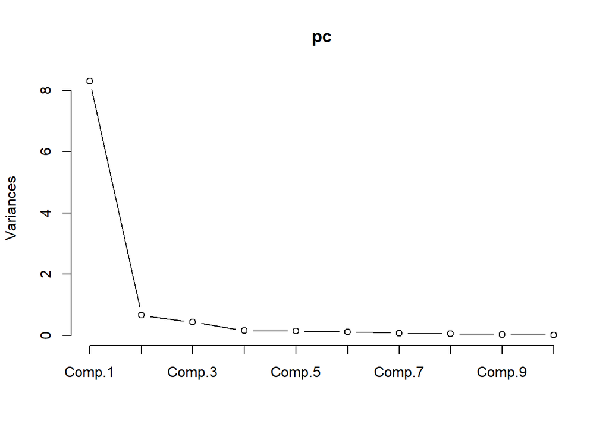

```r
plot(pc, type="lines")
```

#### **Observation :**

#### First Principal Component is sufficient in explaining the maximum variation

### Summarizing Performance By Region

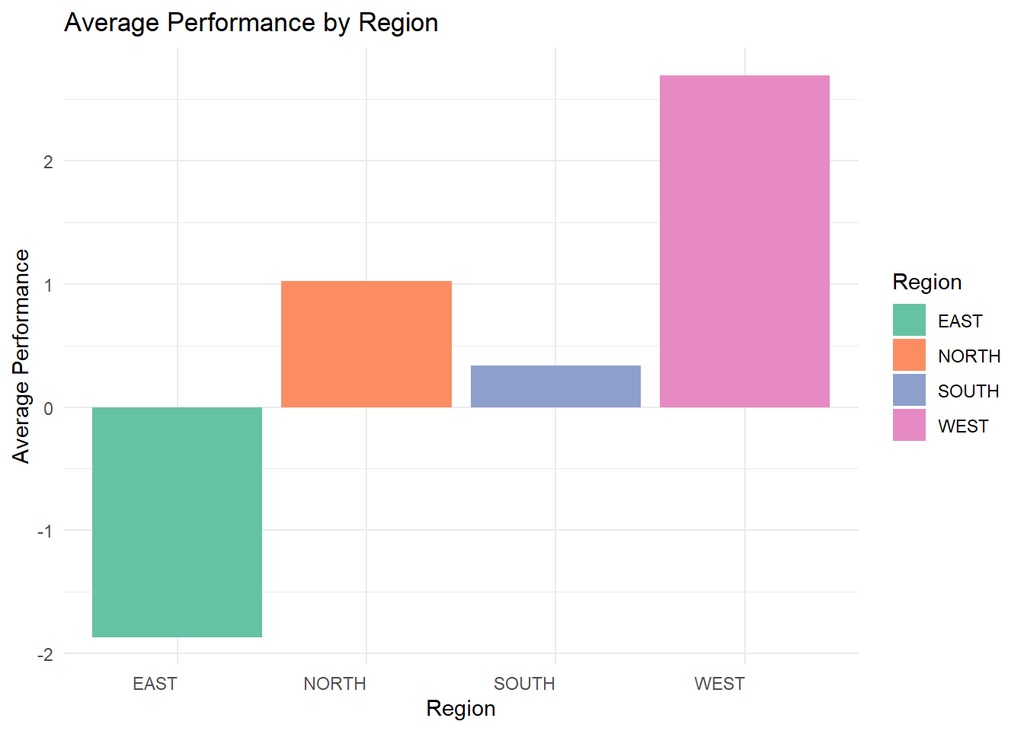

```r
# Group the data by region and calculate the average performance for each region
summary_pc_region<-data %>%
  group_by(Region) %>%
  summarize(performance = round(mean(performance),3))%>%
  as.data.frame()

# Create a bar graph using the specified color palette
ggplot(summary_pc_region, aes(x = Region, y = performance, fill = Region)) +
  geom_bar(stat = "identity") +
  labs(title = "Average Performance by Region", x = "Region", y = "Average Performance") +
  theme_minimal() +
  theme(axis.text.x = element_text(angle = 0, hjust = 1)) +
  scale_fill_brewer(palette = "Set2")
```

#### **Observation:**

#### The analysis of the data reveals notable regional disparities in performance metrics, with the “WEST” region exhibiting the most pronounced positive value, signifying exceptional performance, whereas the “EAST” region records the lowest negative value, indicating subpar performance relative to other regions.